# Applr Test Suite

### gs_40_back_transform_fn

> **Expect:** Same data and model as gs_11 (1/y ~ x, original y scale), but with an EXPLICIT back_transform = (z) 1/z instead of auto-detection. The fitted line must be the same decreasing hyperbolic curve as gs_11. A straight line means the explicit function was ignored.

**Status:** OK

```r
# CASE: gs_40_back_transform_fn
# TYPE: visual
# FUNC: geom_slice
# EXPECT: Same data and model as gs_11 (1/y ~ x, original y scale), but with
#         an EXPLICIT back_transform = \(z) 1/z instead of auto-detection.
#         The fitted line must be the same decreasing hyperbolic curve as
#         gs_11. A straight line means the explicit function was ignored.

source("tests/_setup.R")
set.seed(123)

n <- 50
x <- runif(n, 1, 10)  # positive x only to avoid 1/0
y <- 1/x + rnorm(n, sd = 0.05)
model <- lm(1/y ~ x)

p <- ggplot(data.frame(x, y), aes(x, y)) +
  geom_point(color = "steelblue") +
  geom_slice(model, back_transform = \(z) 1/z) +
  labs(title = "gs_40: Explicit back_transform = \\(z) 1/z",
       subtitle = "EXPECT: Hyperbolic curve, same as gs_11. Straight line = FAIL.")
p
```

**Output (this run):**

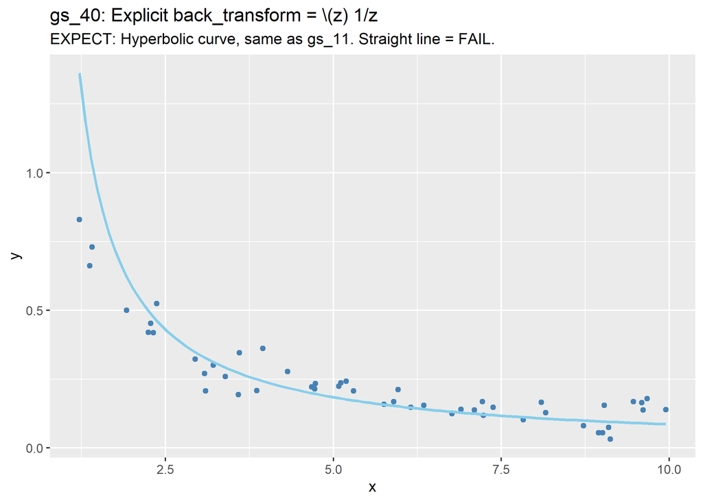

**Reference (ground truth):**

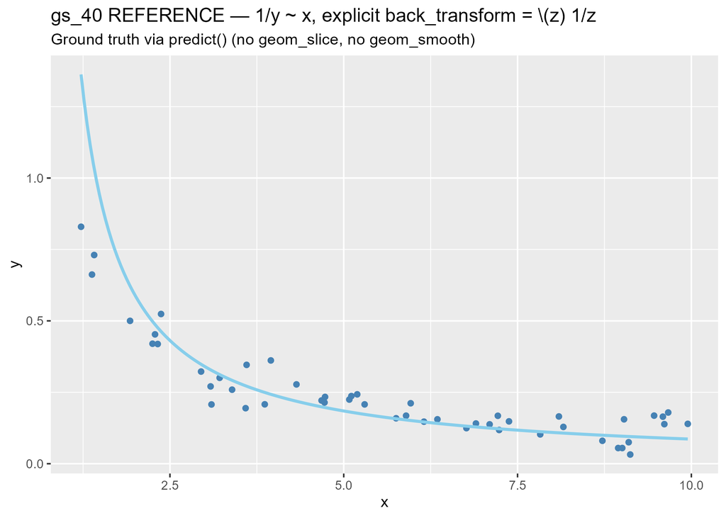

### gs_41_back_transform_string

> **Expect:** Same data and model as gs_09 (log(y) ~ x_pos, original y scale), but with the NAMED-STRING form back_transform = “log” (meaning the response was log-transformed, so predictions are exp()’d) instead of auto-detection. The fitted line must be the same upward exponential curve as gs_09. A straight line = FAIL.

**Status:** OK

```r
# CASE: gs_41_back_transform_string
# TYPE: visual
# FUNC: geom_slice
# EXPECT: Same data and model as gs_09 (log(y) ~ x_pos, original y scale),
#         but with the NAMED-STRING form back_transform = "log" (meaning the
#         response was log-transformed, so predictions are exp()'d) instead
#         of auto-detection. The fitted line must be the same upward
#         exponential curve as gs_09. A straight line = FAIL.

source("tests/_setup.R")
set.seed(123)

n <- 50
x_pos <- runif(n, 0, 10)
y <- exp(x_pos) * exp(rnorm(n, sd = 0.2))  # y = exp(x_pos + noise)
model <- lm(log(y) ~ x_pos)

p <- ggplot(data.frame(x_pos, y), aes(x_pos, y)) +
  geom_point(color = "steelblue") +
  geom_slice(model, back_transform = "log") +
  labs(title = "gs_41: Named-string back_transform = \"log\"",
       subtitle = "EXPECT: Exponential curve, same as gs_09. Straight line = FAIL.")
p
```

**Output (this run):**

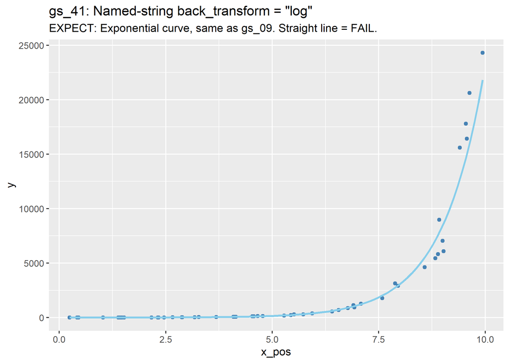

**Reference (ground truth):**

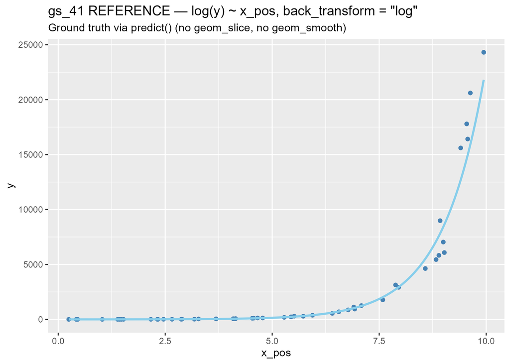

### gs_42_back_transform_false

> **Expect:** Model 1/y ~ x with back_transform = FALSE, plotted with the TRANSFORMED response precomputed as y_trans = 1/y on the y-axis. Predictions stay in 1/y space, matching the axis: ONE STRAIGHT line of slope ~1 through the points. A hyperbolic curve means the opt-out was ignored and it back-transformed anyway.

**Status:** OK

```r
# CASE: gs_42_back_transform_false
# TYPE: visual
# FUNC: geom_slice
# EXPECT: Model 1/y ~ x with back_transform = FALSE, plotted with the
#         TRANSFORMED response precomputed as y_trans = 1/y on the y-axis.
#         Predictions stay in 1/y space, matching the axis: ONE STRAIGHT
#         line of slope ~1 through the points. A hyperbolic curve means the
#         opt-out was ignored and it back-transformed anyway.

source("tests/_setup.R")
set.seed(123)

n <- 50
x <- runif(n, 1, 10)  # positive x only to avoid 1/0
y <- 1/x + rnorm(n, sd = 0.05)
model <- lm(1/y ~ x)

p <- ggplot(data.frame(x, y_trans = 1/y), aes(x, y_trans)) +
  geom_point(color = "steelblue") +
  geom_slice(model, back_transform = FALSE) +
  labs(title = "gs_42: back_transform = FALSE on the transformed axis",
       subtitle = "EXPECT: Straight line, slope ~1. Hyperbolic curve = FAIL.")
p
```

**Output (this run):**

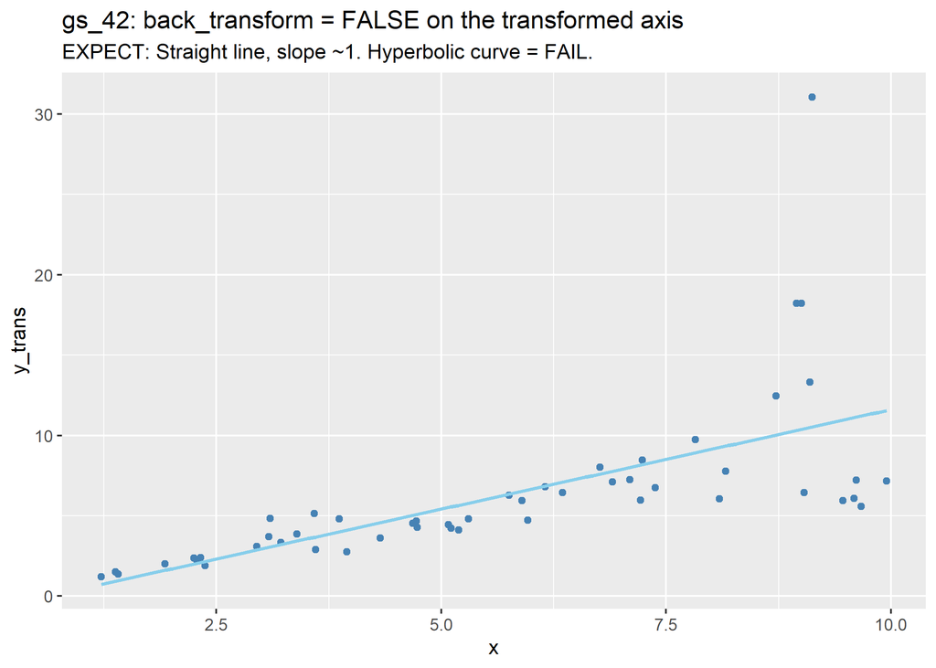

**Reference (ground truth):**

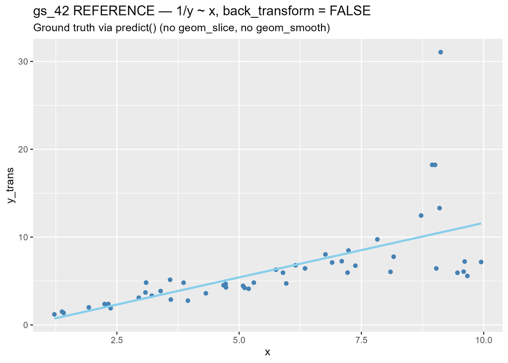

### gs_43_ytransform_inverse_axis

> **Expect:** Model 1/y ~ x, plotted with the TRANSFORMED response mapped inline on the y-axis (aes(x, 1/y)). geom_slice should notice the axis expression matches the model’s response and use predictions as-is: ONE STRAIGHT line of slope ~1 through the points. This is the decreasing-transform analog of gs_26 (which uses log). A hyperbolic curve means it wrongly back-transformed.

**Status:** OK

```r
# CASE: gs_43_ytransform_inverse_axis
# TYPE: visual
# FUNC: geom_slice
# EXPECT: Model 1/y ~ x, plotted with the TRANSFORMED response mapped inline
#         on the y-axis (aes(x, 1/y)). geom_slice should notice the axis
#         expression matches the model's response and use predictions as-is:
#         ONE STRAIGHT line of slope ~1 through the points. This is the
#         decreasing-transform analog of gs_26 (which uses log).
#         A hyperbolic curve means it wrongly back-transformed.

source("tests/_setup.R")
set.seed(123)

n <- 50
x <- runif(n, 1, 10)  # positive x only to avoid 1/0
y <- 1/x + rnorm(n, sd = 0.05)
model <- lm(1/y ~ x)

p <- ggplot(data.frame(x, y), aes(x, 1/y)) +
  geom_point(color = "steelblue") +
  geom_slice(model) +
  labs(title = "gs_43: Inline 1/y on the y-axis (1/y ~ x)",
       subtitle = "EXPECT: Straight line, slope ~1. Hyperbolic curve = FAIL.")
p
```

**Output (this run):**

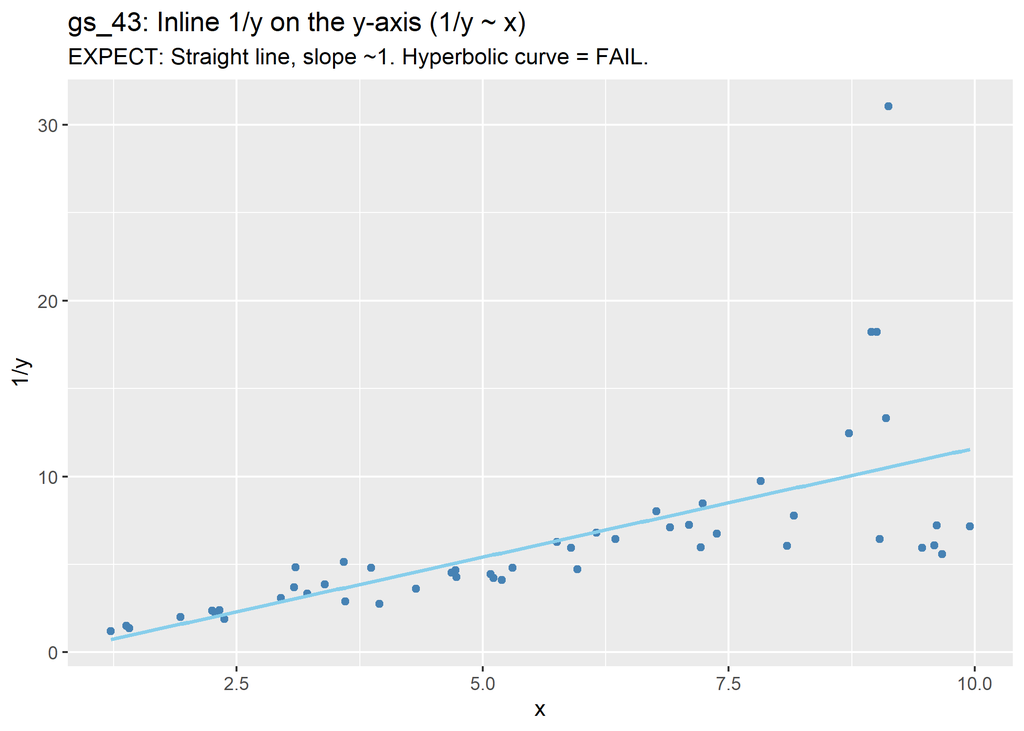

**Reference (ground truth):**

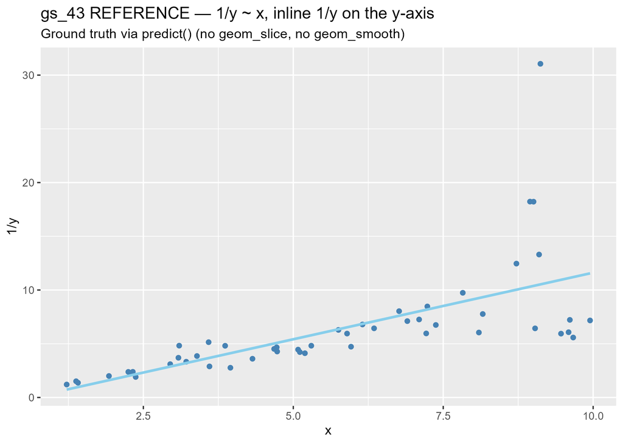

### gs_44_ytransform_exp

> **Expect:** Scatter of x_pos vs y on the ORIGINAL y scale. Model is exp(y) ~ x_pos (y = log(x_pos) + noise), so geom_slice must back-transform via log(fitted): a LOGARITHMIC curve (steep at small x_pos, flattening to the right). Straight line = FAIL. Console message: predictions of exp(y) back-transformed to the y axis.

**Status:** OK

```r
# CASE: gs_44_ytransform_exp
# TYPE: visual
# FUNC: geom_slice
# EXPECT: Scatter of x_pos vs y on the ORIGINAL y scale. Model is
#         exp(y) ~ x_pos (y = log(x_pos) + noise), so geom_slice must
#         back-transform via log(fitted): a LOGARITHMIC curve (steep at
#         small x_pos, flattening to the right). Straight line = FAIL.
#         Console message: predictions of exp(y) back-transformed to the
#         y axis.

source("tests/_setup.R")
set.seed(123)

n <- 50
x_pos <- runif(n, 0.5, 10)  # bounded away from 0 to keep log(x_pos) tame
y <- log(x_pos) + rnorm(n, sd = 0.1)
model <- lm(exp(y) ~ x_pos)

p <- ggplot(data.frame(x_pos, y), aes(x_pos, y)) +
  geom_point(color = "steelblue") +
  geom_slice(model) +
  labs(title = "gs_44: Y-transform exp(y) ~ x_pos",
       subtitle = "EXPECT: Logarithmic curve (back-transformed). Straight line = FAIL.")
p
```

**Output (this run):**

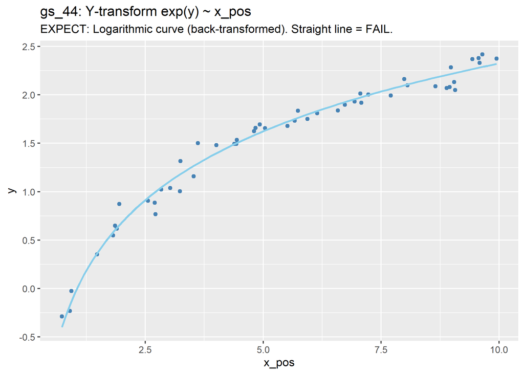

**Console output (this run):**

```
Predictions of `exp(y)` were back-transformed to match the `y` axis.
    To turn this off, use 'back_transform = FALSE'.
```

**Reference (ground truth):**

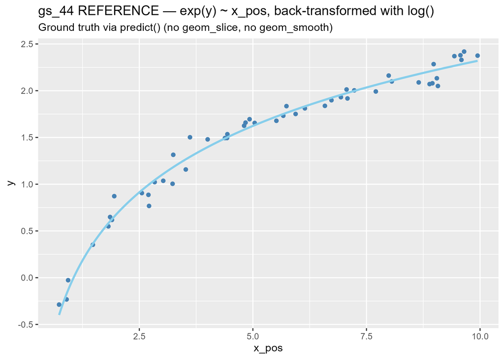

### gs_45_ytransform_square

> **Expect:** Scatter of x_pos vs y on the ORIGINAL y scale. Model is y^2 ~ x_pos (y = sqrt(x_pos) + noise), so geom_slice must back-transform via sqrt(fitted): a SQUARE-ROOT curve (steep at small x_pos, flattening to the right). Straight line = FAIL. Console message: predictions of y^2 back-transformed to the y axis.

**Status:** OK

```r
# CASE: gs_45_ytransform_square
# TYPE: visual
# FUNC: geom_slice
# EXPECT: Scatter of x_pos vs y on the ORIGINAL y scale. Model is
#         y^2 ~ x_pos (y = sqrt(x_pos) + noise), so geom_slice must
#         back-transform via sqrt(fitted): a SQUARE-ROOT curve (steep at
#         small x_pos, flattening to the right). Straight line = FAIL.
#         Console message: predictions of y^2 back-transformed to the y axis.

source("tests/_setup.R")
set.seed(123)

n <- 50
x_pos <- runif(n, 0.5, 10)  # bounded away from 0 so fitted y^2 stays positive
y <- sqrt(x_pos) + rnorm(n, sd = 0.05)
model <- lm(y^2 ~ x_pos)

p <- ggplot(data.frame(x_pos, y), aes(x_pos, y)) +
  geom_point(color = "steelblue") +
  geom_slice(model) +
  labs(title = "gs_45: Y-transform y^2 ~ x_pos",
       subtitle = "EXPECT: Square-root curve (back-transformed). Straight line = FAIL.")
p
```

**Output (this run):**

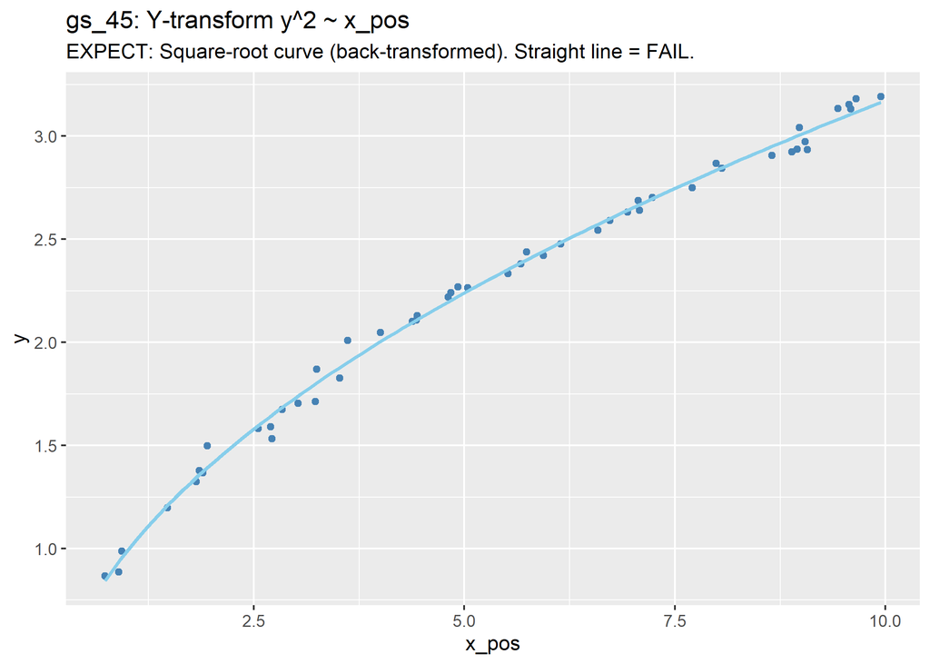

**Console output (this run):**

```
Predictions of `y^2` were back-transformed to match the `y` axis.
    To turn this off, use 'back_transform = FALSE'.
```

**Reference (ground truth):**

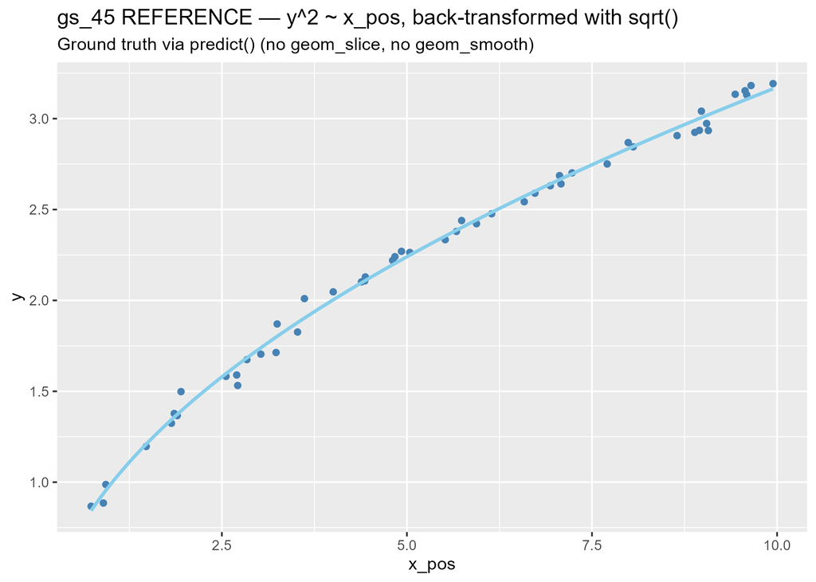

### gs_46_both_intervals

> **Expect:** Same model and slice as gs_33/gs_34 (mpg ~ disp + hp at hp = 110), with TWO geom_slice layers: confidence and prediction intervals together — a NARROW ribbon nested inside a WIDE one, sharing one straight downward line (see reference).

**Status:** OK

```r
# CASE: gs_46_both_intervals
# TYPE: visual
# FUNC: geom_slice
# EXPECT: Same model and slice as gs_33/gs_34 (mpg ~ disp + hp at hp = 110),
#         with TWO geom_slice layers: confidence and prediction intervals
#         together — a NARROW ribbon nested inside a WIDE one, sharing one
#         straight downward line (see reference).

source("tests/_setup.R")

model <- lm(mpg ~ disp + hp, data = mtcars)

ggplot(mtcars, aes(disp, mpg)) +
  geom_point() +
  geom_slice(model, predict_vars = list(hp = 110), interval = "prediction") +
  geom_slice(model, predict_vars = list(hp = 110), interval = "confidence")
```

**Output (this run):**

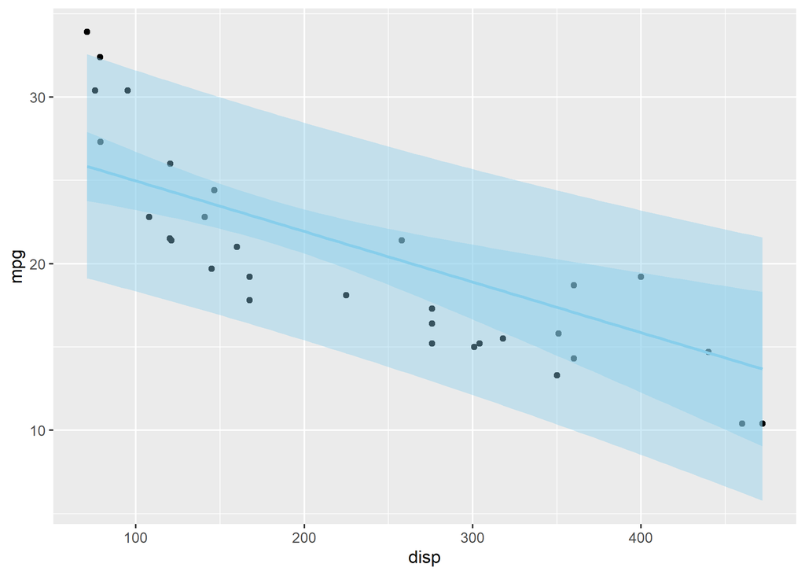

**Reference (ground truth):**

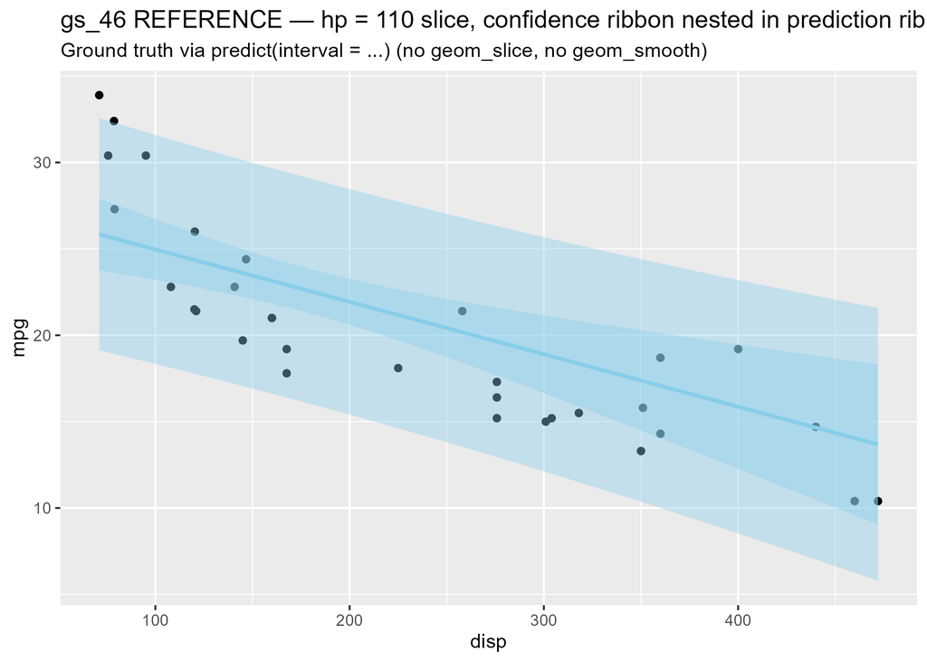

### gs_47_real_data_interaction_grouped

> **Expect:** mpg dataset (displ vs hwy, colored by drv) with ONE geom_slice call drawing three quadratic curves, one per drive type in that group’s natural color (model hwy ~ displ + I(displ^2) + displ:drv). Each curve should follow its own group’s points and span only its own group’s displ range.

**Status:** OK

```r
# CASE: gs_47_real_data_interaction_grouped
# TYPE: visual
# FUNC: geom_slice
# EXPECT: mpg dataset (displ vs hwy, colored by drv) with ONE geom_slice call
#         drawing three quadratic curves, one per drive type in that group's
#         natural color (model hwy ~ displ + I(displ^2) + displ:drv). Each
#         curve should follow its own group's points and span only its own
#         group's displ range.

source("tests/_setup.R")

model <- lm(hwy ~ displ + I(displ^2) + displ:drv, data = mpg)

ggplot(mpg, aes(displ, hwy, color = drv)) +
  geom_point() +
  geom_slice(model)
```

**Output (this run):**

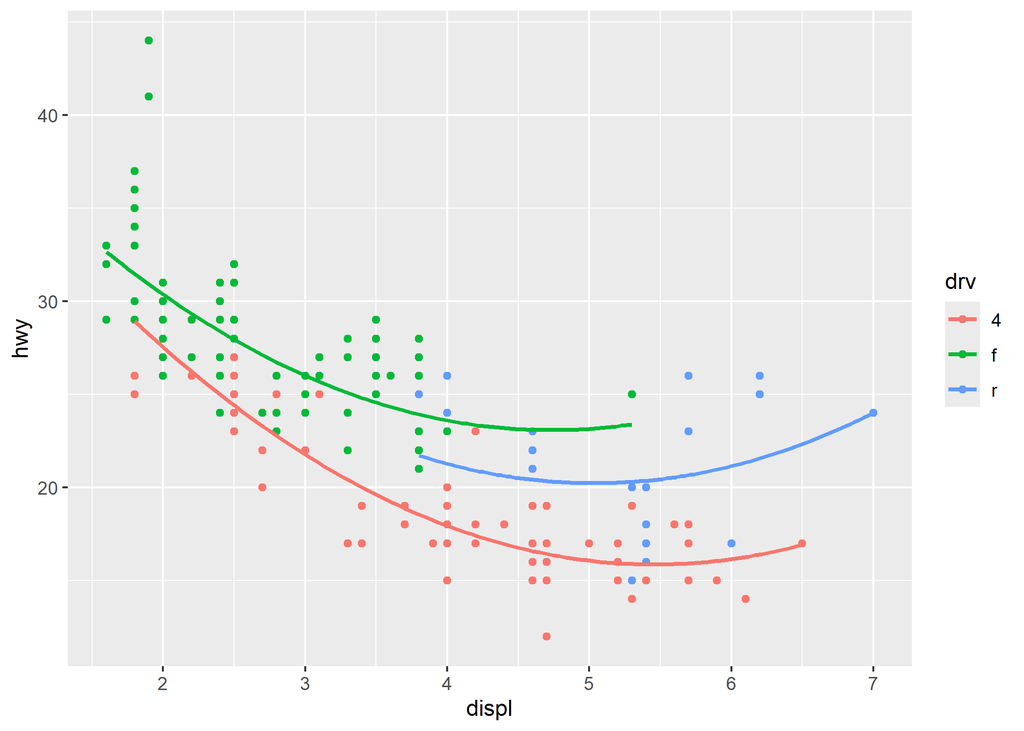

**Reference (ground truth):**

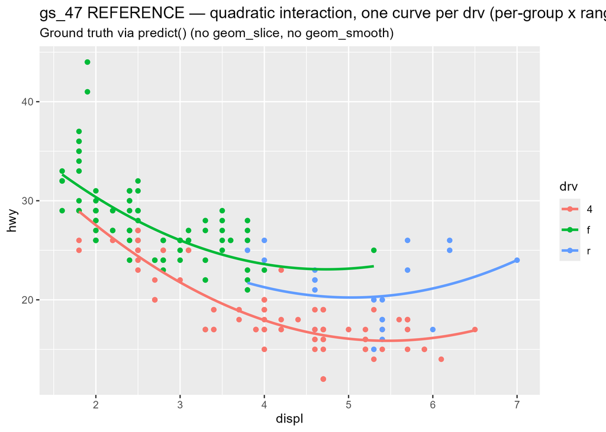

### gs_48_err_discrete_x_axis

> **Expect:** A factor predictor mapped to the x-axis makes the x scale discrete; geom_slice needs a continuous axis to draw a line. A clear error: “geom_slice() needs a continuous x-axis, but the x scale is discrete.” (imputation messages for the held variable may print first).

**Status:** OK

```r
# CASE: gs_48_err_discrete_x_axis
# TYPE: console
# FUNC: geom_slice
# EXPECT: A factor predictor mapped to the x-axis makes the x scale discrete;
#         geom_slice needs a continuous axis to draw a line. A clear error:
#         "geom_slice() needs a continuous x-axis, but the x scale is
#         discrete." (imputation messages for the held variable may print
#         first).

source("tests/_setup.R")

mtcars2 <- mtcars
mtcars2$cyl <- factor(mtcars2$cyl)
model <- lm(mpg ~ cyl + hp, data = mtcars2)

try_show(ggplot(mtcars2, aes(cyl, mpg)) +
           geom_point() +
           geom_slice(model))
```

**Output (this run):**

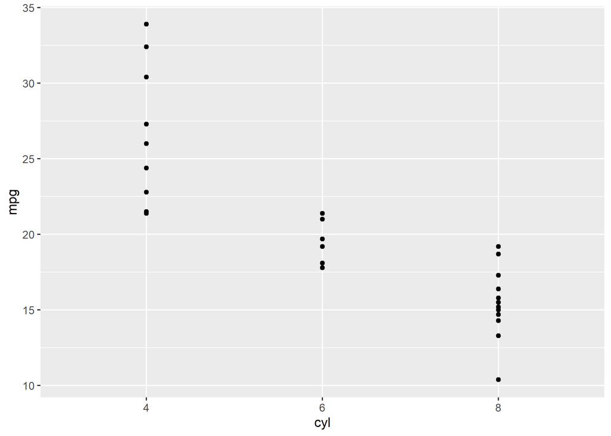

**Console output (this run):**

```
Message: Value for `hp` not specified - Used mean: 146.7
    To choose a slice, use 'predict_vars = list(hp = 146.7)'.
Warning: Computation failed in `stat_slice()`.
Caused by error:
! geom_slice() needs a continuous x-axis, but the x scale is discrete.
    Map a numeric variable or expression to this axis.
```

### gs_49_band_two_values

> **Expect:** Two parallel skyblue lines (x_pos = 1 lower, x_pos = 9 upper) with a translucent skyblue ribbon filling the region between them — a projection band. band = TRUE spans the min and max values of the one multi-value predict_vars variable; the edge lines still draw as ordinary slices.

**Status:** OK

```r
# CASE: gs_49_band_two_values
# TYPE: visual
# FUNC: geom_slice
# EXPECT: Two parallel skyblue lines (x_pos = 1 lower, x_pos = 9 upper) with a
#         translucent skyblue ribbon filling the region between them — a
#         projection band. band = TRUE spans the min and max values of the one
#         multi-value predict_vars variable; the edge lines still draw as
#         ordinary slices.

source("tests/_setup.R")
set.seed(123)

n <- 50
x <- runif(n, -10, 10)
x_pos <- runif(n, 0, 10)
y <- x + x_pos + rnorm(n)
dat <- data.frame(x, x_pos, y)
model <- lm(y ~ x + x_pos, data = dat)

ggplot(dat, aes(x, y)) +
  geom_point() +
  geom_slice(model, predict_vars = list(x_pos = c(1, 9)), band = TRUE)
```

**Output (this run):**

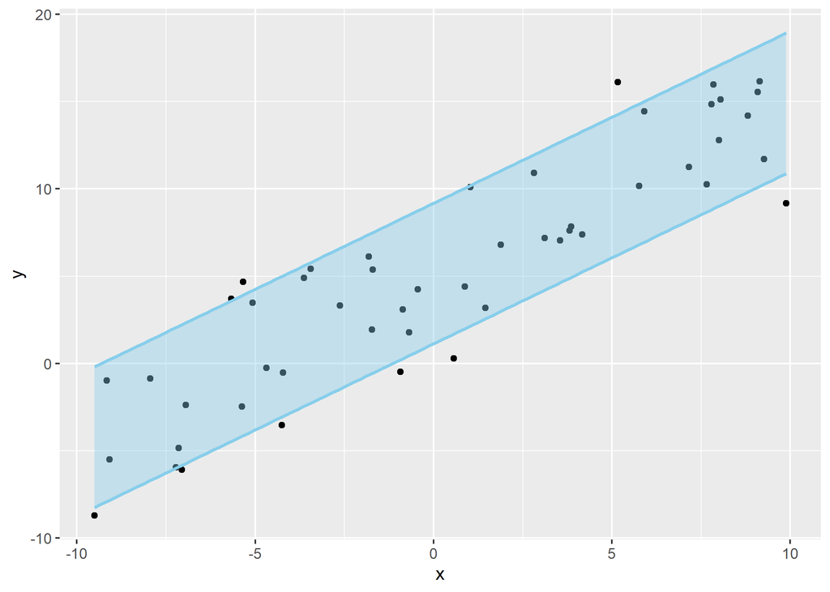

**Reference (ground truth):**

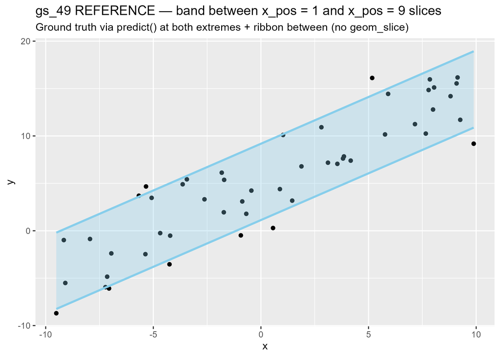

### gs_50_band_imputed_range

> **Expect:** A projection band with NO values pinned by the user: band = “x_pos” with x_pos absent from predict_vars imputes the band range from the data — the observed min and max of x_pos. Two skyblue edge lines at those imputed extremes with a translucent skyblue ribbon between them. The band should be wider than gs_49’s (full data range, not 1-9). Console message: band range for x_pos not specified, imputed from the min/max data range.

**Status:** OK

```r
# CASE: gs_50_band_imputed_range
# TYPE: visual
# FUNC: geom_slice
# EXPECT: A projection band with NO values pinned by the user: band = "x_pos"
#         with x_pos absent from predict_vars imputes the band range from the
#         data — the observed min and max of x_pos. Two skyblue edge lines at
#         those imputed extremes with a translucent skyblue ribbon between
#         them. The band should be wider than gs_49's (full data range, not
#         1-9). Console message: band range for x_pos not specified, imputed
#         from the min/max data range.

source("tests/_setup.R")
set.seed(123)

n <- 50
x <- runif(n, -10, 10)
x_pos <- runif(n, 0, 10)
y <- x + x_pos + rnorm(n)
dat <- data.frame(x, x_pos, y)
model <- lm(y ~ x + x_pos, data = dat)

ggplot(dat, aes(x, y)) +
  geom_point() +
  geom_slice(model, band = "x_pos")
```

**Output (this run):**

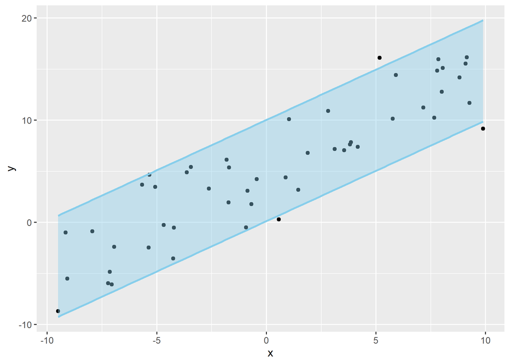

**Console output (this run):**

```
Band range for `x_pos` not specified - used the min/max data range: 0.006248 to 9.85.
    To choose the range, use 'predict_vars = list(x_pos = c(0.006248, 9.85))'.
```

**Reference (ground truth):**

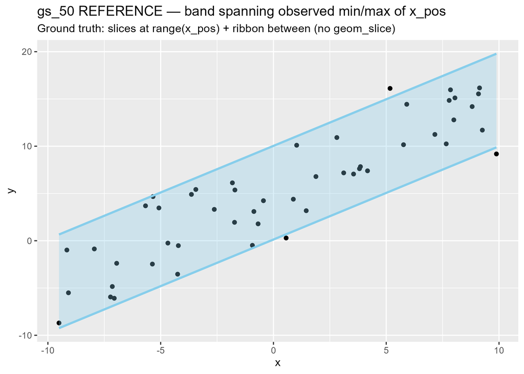

### gs_51_band_grouped_faceted

> **Expect:** mpg (displ vs hwy) colored by drv and faceted by year, with ONE geom_slice call drawing a projection band per drive type in each facet: edge lines at cyl = 4 and cyl = 8 in that group’s natural color, a translucent ribbon of the same color between them. Each group’s band spans only its own group’s displ range within its facet. This mirrors the house-price example plot (bands per color group across facets).

**Status:** OK

```r
# CASE: gs_51_band_grouped_faceted
# TYPE: visual
# SIZE: 10x5
# FUNC: geom_slice
# EXPECT: mpg (displ vs hwy) colored by drv and faceted by year, with ONE
#         geom_slice call drawing a projection band per drive type in each
#         facet: edge lines at cyl = 4 and cyl = 8 in that group's natural
#         color, a translucent ribbon of the same color between them. Each
#         group's band spans only its own group's displ range within its
#         facet. This mirrors the house-price example plot (bands per color
#         group across facets).

source("tests/_setup.R")

model <- lm(hwy ~ displ * drv + cyl, data = mpg)

ggplot(mpg, aes(displ, hwy, color = drv)) +
  geom_point() +
  geom_slice(model, predict_vars = list(cyl = c(4, 8)), band = TRUE) +
  facet_wrap(~year)
```

**Output (this run):**

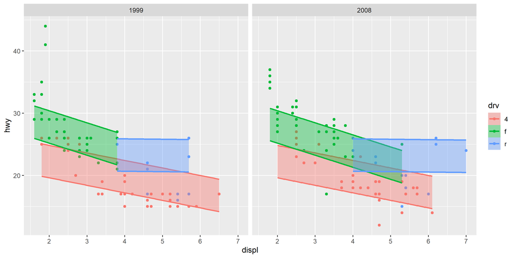

**Reference (ground truth):**

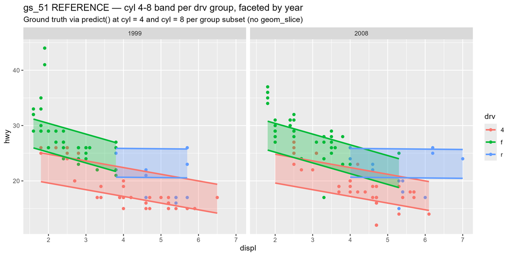

### gs_52_band_true_no_predict_vars

> **Expect:** band = TRUE with NO predict_vars at all. The model has exactly one non-axis predictor (x_pos), so it is unambiguous which variable bands: x_pos, spanning its observed min/max from the data. Two skyblue edge lines at those extremes with a translucent skyblue ribbon between them — identical result to gs_50’s band = “x_pos”, including the same console message (band range for x_pos imputed from the min/max data range).

**Status:** OK

```r
# CASE: gs_52_band_true_no_predict_vars
# TYPE: visual
# FUNC: geom_slice
# EXPECT: band = TRUE with NO predict_vars at all. The model has exactly one
#         non-axis predictor (x_pos), so it is unambiguous which variable
#         bands: x_pos, spanning its observed min/max from the data. Two
#         skyblue edge lines at those extremes with a translucent skyblue
#         ribbon between them — identical result to gs_50's band = "x_pos",
#         including the same console message (band range for x_pos imputed
#         from the min/max data range).

source("tests/_setup.R")
set.seed(123)

n <- 50
x <- runif(n, -10, 10)
x_pos <- runif(n, 0, 10)
y <- x + x_pos + rnorm(n)
dat <- data.frame(x, x_pos, y)
model <- lm(y ~ x + x_pos, data = dat)

ggplot(dat, aes(x, y)) +
  geom_point() +
  geom_slice(model, band = TRUE)
```

**Output (this run):**

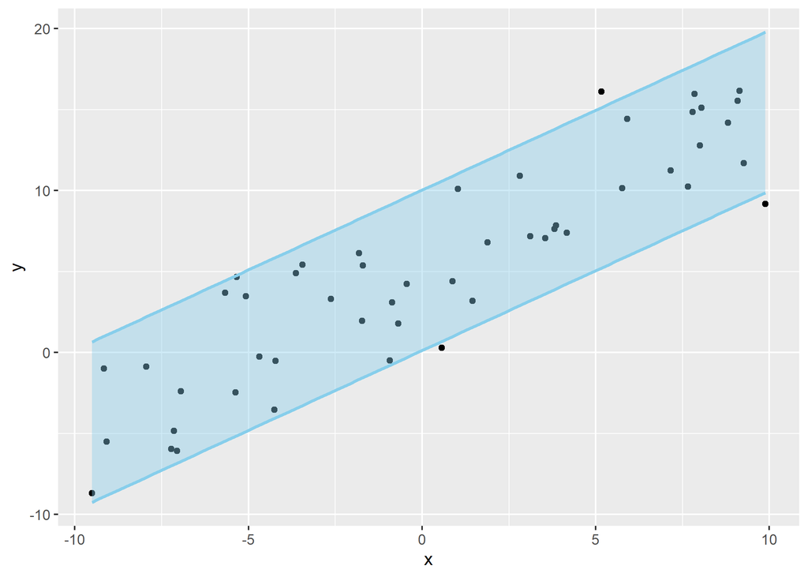

**Console output (this run):**

```
Band range for `x_pos` not specified - used the min/max data range: 0.006248 to 9.85.
    To choose the range, use 'predict_vars = list(x_pos = c(0.006248, 9.85))'.
```

**Reference (ground truth):**

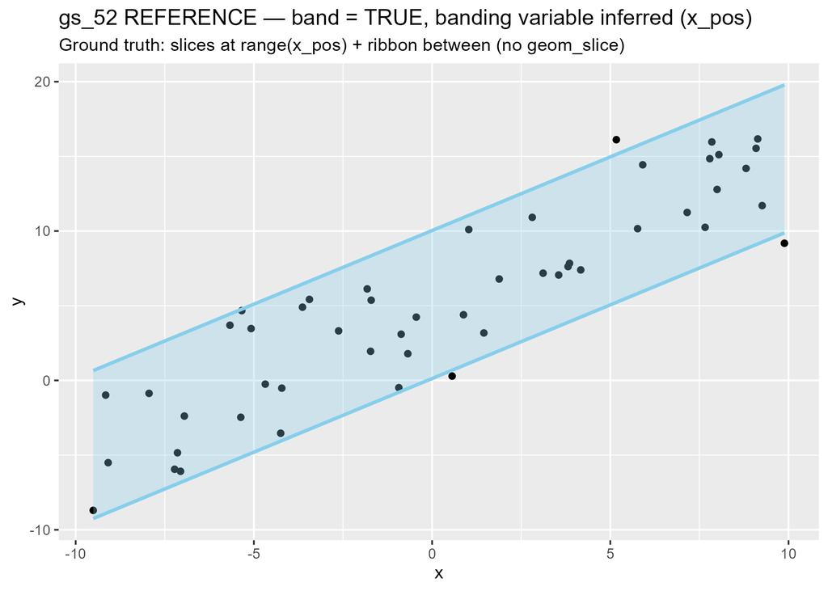

### gs_53_warn_band_nothing_to_band

> **Expect:** A clear, student-readable warning: band = TRUE but the model has no variable to band — y ~ x uses the x-axis variable as its only predictor, so there is nothing to span. The warning should name the problem, say no band is drawn, and hint that a band needs a second predictor (or a band = “variable” choice). The slice line still draws — no further errors.

**Status:** OK

```r
# CASE: gs_53_warn_band_nothing_to_band
# TYPE: visual
# FUNC: geom_slice
# EXPECT: A clear, student-readable warning: band = TRUE but the model has no
#         variable to band — y ~ x uses the x-axis variable as its only
#         predictor, so there is nothing to span. The warning should name the
#         problem, say no band is drawn, and hint that a band needs a second
#         predictor (or a band = "variable" choice). The slice line still
#         draws — no further errors.

source("tests/_setup.R")
set.seed(123)

n <- 50
x <- runif(n, -10, 10)
y <- x + rnorm(n)
dat <- data.frame(x, y)
model <- lm(y ~ x, data = dat)

try_show(ggplot(dat, aes(x, y)) +
           geom_point() +
           geom_slice(model, band = TRUE))
```

**Output (this run):**

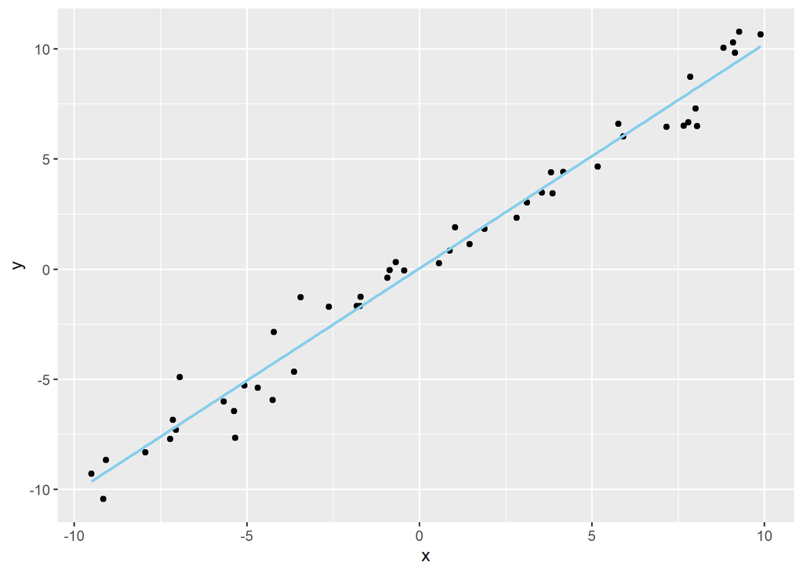

**Console output (this run):**

```
Warning: band = TRUE, but no variable is available - every model predictor is already shown on the plot. No band is drawn.
    A projection band spans a predictor not represented on the plot; add another predictor to the model, such as `lm(y ~ x + new_predictor, ...)`
```

### gs_54_warn_band_var_not_in_model

> **Expect:** A clear, student-readable warning: band = “x3” names a variable that exists in the data set but is NOT a predictor in the model, so no band is possible. The warning should say the variable is not in the model, say no band is drawn, and hint at predictors a band could actually use (here x_pos, not the x-axis variable), plus band = TRUE to choose automatically. The slice line still draws — no further errors.

**Status:** OK

```r
# CASE: gs_54_warn_band_var_not_in_model
# TYPE: visual
# FUNC: geom_slice
# EXPECT: A clear, student-readable warning: band = "x3" names a variable that
#         exists in the data set but is NOT a predictor in the model, so no
#         band is possible. The warning should say the variable is not in the
#         model, say no band is drawn, and hint at predictors a band could
#         actually use (here x_pos, not the x-axis variable), plus band = TRUE
#         to choose automatically. The slice line still draws — no further
#         errors.

source("tests/_setup.R")
set.seed(123)

n <- 50
x <- runif(n, -10, 10)
x_pos <- runif(n, 0, 10)
x3 <- runif(n, 0, 100)
y <- x + x_pos + rnorm(n)
dat <- data.frame(x, x_pos, x3, y)
model <- lm(y ~ x + x_pos, data = dat)

try_show(ggplot(dat, aes(x, y)) +
           geom_point() +
           geom_slice(model, band = "x3"))
```

**Output (this run):**

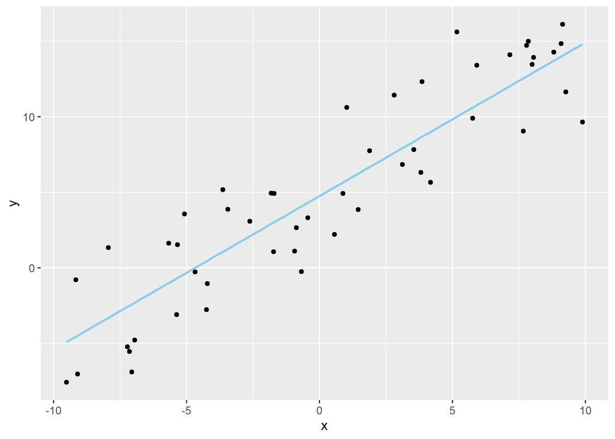

**Console output (this run):**

```
Warning: `band` variable "x3" is not a predictor in the model. No band is drawn.
    Use 'band = "x_pos"', or 'band = TRUE' to choose automatically.
Message: Value for `x_pos` not specified - Used mean: 4.77
    To choose a slice, use 'predict_vars = list(x_pos = 4.77)'.
```

### gs_55_warn_band_var_on_x_axis

> **Expect:** A clear, student-readable warning: band = “x” names the predictor on the plot’s x-axis, which already varies along the line, so it cannot band and no band is drawn. The hint should name predictors a band could actually use (here x_pos) and offer band = TRUE to choose automatically. The slice line still draws — no further errors.

**Status:** OK

```r
# CASE: gs_55_warn_band_var_on_x_axis
# TYPE: visual
# FUNC: geom_slice
# EXPECT: A clear, student-readable warning: band = "x" names the predictor on
#         the plot's x-axis, which already varies along the line, so it
#         cannot band and no band is drawn. The hint should name predictors a
#         band could actually use (here x_pos) and offer band = TRUE to choose
#         automatically. The slice line still draws — no further errors.

source("tests/_setup.R")
set.seed(123)

n <- 50
x <- runif(n, -10, 10)
x_pos <- runif(n, 0, 10)
y <- x + x_pos + rnorm(n)
dat <- data.frame(x, x_pos, y)
model <- lm(y ~ x + x_pos, data = dat)

try_show(ggplot(dat, aes(x, y)) +
           geom_point() +
           geom_slice(model, band = "x"))
```

**Output (this run):**

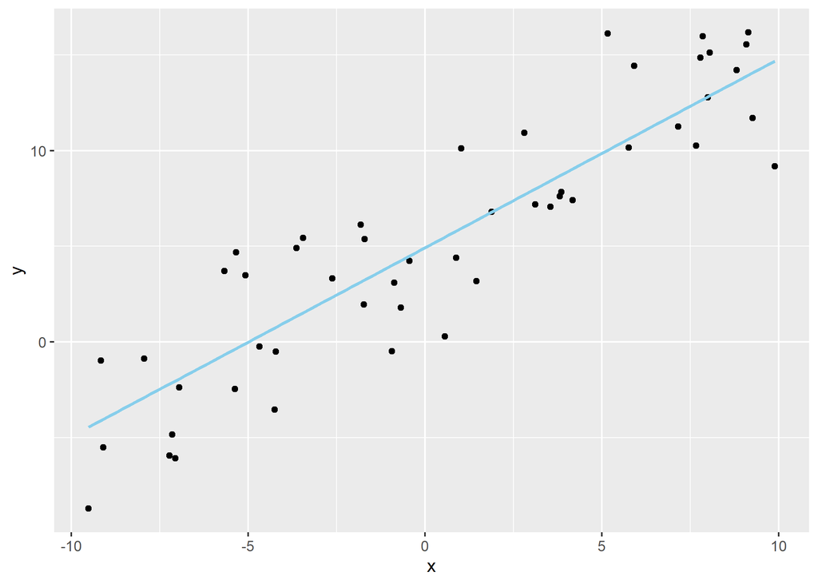

**Console output (this run):**

```
Warning: `band` variable `x` is on the x-axis, so it already varies along the line. No band is drawn.
    Use 'band = "x_pos"', or 'band = TRUE' to choose automatically.
Message: Value for `x_pos` not specified - Used mean: 4.77
    To choose a slice, use 'predict_vars = list(x_pos = 4.77)'.
```

### gs_56_warn_band_var_pinned

> **Expect:** A clear, student-readable warning: band = “drv” names a predictor pinned per group by aes(color = drv), so each line already uses its own drv value and it cannot band, so no band is drawn. The hint should name predictors a band could actually use (here cyl) and offer band = TRUE. The slice lines still draw — no further errors.

**Status:** OK

```r
# CASE: gs_56_warn_band_var_pinned
# TYPE: visual
# FUNC: geom_slice
# EXPECT: A clear, student-readable warning: band = "drv" names a predictor
#         pinned per group by aes(color = drv), so each line already uses its
#         own drv value and it cannot band, so no band is drawn. The hint
#         should name predictors a band could actually use (here cyl) and
#         offer band = TRUE. The slice lines still draw — no further errors.

source("tests/_setup.R")

model <- lm(hwy ~ displ * drv + cyl, data = mpg)

try_show(ggplot(mpg, aes(displ, hwy, color = drv)) +
           geom_point() +
           geom_slice(model, band = "drv"))
```

**Output (this run):**

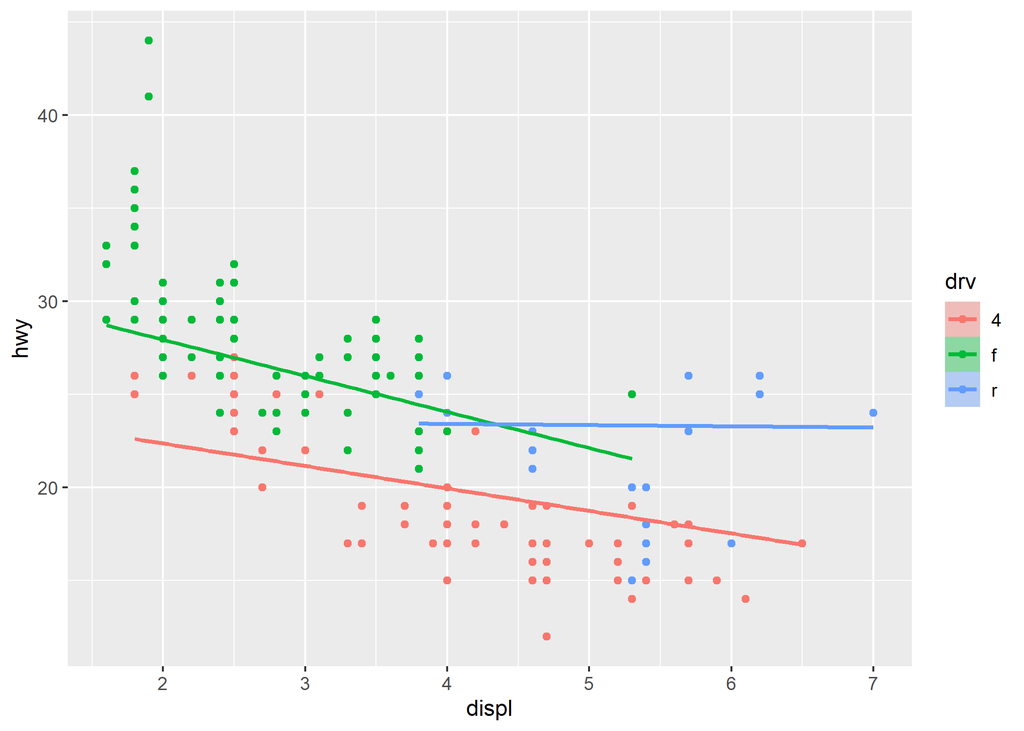

**Console output (this run):**

```
Warning: `band` variable `drv` is used by the plot's grouping or faceting, so each line already uses its own value. No band is drawn.
    Use 'band = "cyl"', or 'band = TRUE' to choose automatically.
Message: Value for `cyl` not specified - Used mean: 5.889
    To choose a slice, use 'predict_vars = list(cyl = 5.889)'.
```